# Problem Set 2 - Carter Hardy

2025-02-05

# Problem 1

#### Load the dataset

```r
birth <- read.table("/Users/carterhardy/spring 2025 UU/Prob-and-Stats-BMI6106/Problem set 2/birthwt.txt", header = TRUE, sep = " ")
```

### A. How many observations are in the dataset?

```r
#total number of observations
n <- nrow(birth)

n
```

```
## [1] 189
```

There are **189** observations

### B. Examine each column

#### Columns:

low: Categorical, discrete variable

age: Numerical, continuous variable

lwt: Numerical, continuous variable

race: Categorical, discrete variable

smoke: Categorical, discrete variable

ptl: Numerical, discrete variable

ht: Categorical, discrete variable

ui: Categorical, discrete variable

ftv: Numerical, discrete variable

bwt: Numerical, continuous variable

#### Discrete:

low: Binary, 0 1

race: Nominal, 1 2 3

smoke: Binary, 0 1

ptl: Ordinal, 0 1 2 3

ht:Binary, 0 1

ui: Binary, 0 1

ftv: Ordinal, 0 1 2 3 4 6

```r
#code to find the levels for each discrete variable
unique(birth$low)
```

```
## [1] 0 1
```

```r
unique(birth$race)
```

```
## [1] 2 3 1
```

```r
unique(birth$smoke)
```

```
## [1] 0 1
```

```r
unique(birth$ptl)
```

```
## [1] 0 1 2 3
```

```r
unique(birth$ht)
```

```
## [1] 0 1
```

```r
unique(birth$ui)
```

```
## [1] 1 0
```

```r
unique(birth$ftv)
```

```
## [1] 0 3 1 2 4 6
```

#### Continuous

age lwt bwt

```r
library(psych)

#code to get descriptive stats for our cont. variables
describe(birth[, c("age", "lwt", "bwt")])
```

```
##     vars   n    mean     sd median trimmed    mad min  max range  skew kurtosis
## age    1 189   23.24   5.30     23   22.90   5.93  14   45    31  0.71     0.53
## lwt    2 189  129.81  30.58    121  126.07  20.76  80  250   170  1.38     2.25
## bwt    3 189 2944.66 729.02   2977 2961.84 819.88 709 4990  4281 -0.21    -0.14
##        se
## age  0.39
## lwt  2.22
## bwt 53.03
```

We can see the mean, sd, and median for age is **23.24, 5.30, and 23.**

We can see the mean, sd, and median for lwt is **129.81, 30.58, and 121.**

We can see the mean, sd, and median for bwt is **2944.66, 729.02, and 2977.**

### C. How many individuals older than 30 smoke?

```r
#Filter the age of observations to those above 30
filtered_birth = birth[birth$age > 30, ]

#out of those above the age 30, sum of the ones who smoke
sum(filtered_birth$smoke == 1)
```

```
## [1] 8
```

### D. plot a histogram of birth weights

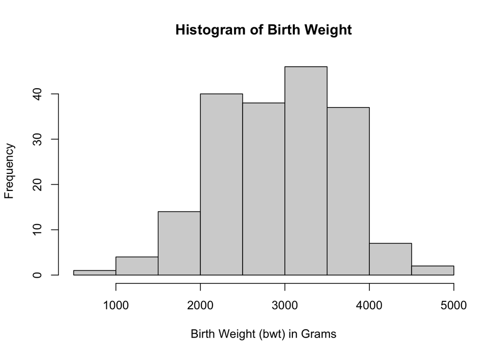

```r
#this code creates a histogram of birth weights
hist(birth$bwt,
     main = "Histogram of Birth Weight",
     xlab = "Birth Weight (bwt) in Grams")
```

### G. Calculate the probability of randomly selecting an individual that has either a low birth weight or a mother who was a smoker.

In order to find this, we will calculate P(A or B) = P(A) + P(B) - P(A & B)

```r
#prob of low birth weight
p_low = sum(birth$low == 1) / n

#prob of a mother who was a smoker
p_smoker = sum(birth$smoke == 1) / n

#prob of low birth weight and mother who was a smoker
p_both = sum(birth$smoke == 1 & birth$low == 1) / n

#P(A or B) = P(A) + P(B) - P(A & B)
p_union = p_low + p_smoker - p_both

p_union
```

```
## [1] 0.5449735
```

### H. Calculate the probability of randomly selecting an individual that is white and has more than 3 physician visits during the first trimester.

```r
#P(A & B)

#probability of both (individual is white and has more than 3 visits during first tri) divided by the total number of observations
joint <- sum(birth$race == 1 & birth$ftv > 3) / n

joint
```

```
## [1] 0.01058201
```

# Problem 2

### A. What is the probability that given a positive mammogram exam, a woman has a positive cancer diagnosis? Assume that the breast cancer incidence rate is 1%, the positivity rate for the exam if a patient has cancer is 90%, and there is a false positive rate of 8% for the exam.

p(postive cancer diagnosis | positive mammogram exam)

P(cancer) = .01

P(positive | cancer) = .9

false positive = P(positive | no cancer) = .08

P(cancer | positive test) = $\frac{P(positive | cancer) * P(cancer)}{P(positivetest)}$

First we need to find P(positive test): P(positive) = P(pos | cancer) * p(cancer) + p(pos | no cancer) * p(no cancer)

```r
prob_positive <- (.9)*(.01) + (.08)*(.99)
prob_positive
```

```
## [1] 0.0882
```

Next, we can now use Bayes to calculate the probability of having cancer given having a positive test  
P(cancer | positive test) = $\frac{P(positive | cancer) * P(cancer)}{P(positivetest)}$

```r
prob_can_given_positive <- (.9 * .01) / prob_positive
prob_can_given_positive
```

```
## [1] 0.1020408
```

### B. For every attempt to call your friend, there is a 70% probability of actually speaking with them. Calculate the probability of having exactly 12 successes in 20 attempts.

```r
#Binomial distribution

#number of trials
calls <- 20

#prob of success
p <- 0.7

#number of successes
k <- 12

#compute probability using binomial distribution
prob <- dbinom(k, calls, p)

prob
```

```
## [1] 0.1143967
```

The probability of having exactly 12 success in 20 attempts is **.114**

### C. The cholesterol levels of a group of patients are normally distributed with a mean of 200 mg/dL and a standard deviation of 25 mg/dL.

#### 1. What is the probability that a randomly selected patient will have a cholesterol level between 180 mg/dL and 220 mg/dL?

```r
#probability of 180 and below P(X<= 180)
low <- pnorm(180, 200, 25)

#probability of 220 and below P(X<= 220)
high <- pnorm(220, 200, 25)

#probability between 220 and 180 by subtracting P(X<= 220) - P(X<= 180)
high - low
```

```
## [1] 0.5762892
```

#### 2. Additionally, calculate the interquartile range (IQR) of the cholesterol levels.

```r
#25th percentile
Q1 <- qnorm(.25, 220, 25)

#75th percentile
Q3 <- qnorm(.75, 220, 25)

#IQR
IQR_value <- Q3 - Q1


IQR_value
```

```
## [1] 33.72449
```

#### 3. Discuss how these statistics can be used to identify patients at risk of cardiovascular diseases

These stats help us assess normal v abnormal values and detect outliers. Understanding the probability of a cholesterol level falling within a given range helps us determine how common or uncommon certain cholesterol levels are within our population. Similarly, the IQR provides insight into the spread and variability of cholesterol levels, highlighting where the middle 50% of values lie.

#### 4. How the distribution might change if the standard deviation were reduced to 15 mg/dL?

If we reduced the sd to 15, the distribution of cholesterol levels would become more concentrated around the mean. Since SD represents the spread of the data, a smaller SD means values are clustered more tightly, increasing the probability that a randomly selected patient will have cholesterol levels between 180 and 220 mg/dL. With less variability, more data points will fall within this range.  
The IQR would decrease as well. A lower SD compresses the data, causing most cholesterol levels to be closer together.

# Problem 3

### Part 1

1. Load the dataset in your preferred language and perform an initial exploration. What are the dimensions of the dataset? Are there any missing values? (2 pts)

```r
data <- read.csv('/Users/carterhardy/spring 2025 UU/Prob-and-Stats-BMI6106/Problem set 2/Breast_cancer_Naive.csv')

dim(data)
```

```
## [1] 569  32
```

There are 569 rows (observations) by 32 columns

```r
anyNA(data)
```

```
## [1] FALSE
```

there is not any missing values

2. Summarize the key characteristics of the dataset using appropriate descriptive statistics and visualizations. What are the distributions of numerical features?

```r
library(dplyr)
data %>%
  summarize(
    unique_values = n_distinct(diagnosis),
    most_common = names(sort(table(diagnosis), decreasing = TRUE))[1]
  )
```

```
##   unique_values most_common
## 1             2           B
```

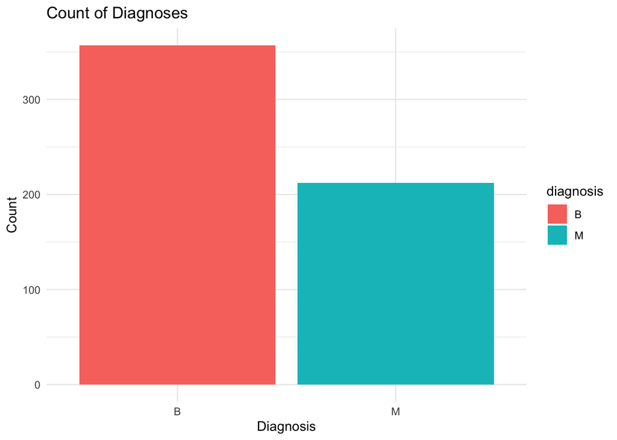

```r
library(ggplot2)
ggplot(data, aes(x = diagnosis, fill = diagnosis)) +
  geom_bar() +
  labs(title = "Count of Diagnoses", x = "Diagnosis", y = "Count") +
  theme_minimal()
```

```r
library(skimr)
library(dplyr)
options(scipen = 999)
skim(data %>% select(-c(1, 2)))
```

Data summary

| Name | data %>% select(-c(1, 2)) |
| --- | --- |
| Number of rows | 569 |
| Number of columns | 30 |
| _______________________ |  |
| Column type frequency: |  |
| numeric | 30 |
| ________________________ |  |
| Group variables | None |

**Variable type: numeric**

| skim_variable | n_missing | complete_rate | mean | sd | p0 | p25 | p50 | p75 | p100 | hist |
| --- | --- | --- | --- | --- | --- | --- | --- | --- | --- | --- |
| radius_mean | 0 | 1 | 14.13 | 3.52 | 6.98 | 11.70 | 13.37 | 15.78 | 28.11 | ▂▇▃▁▁ |
| texture_mean | 0 | 1 | 19.29 | 4.30 | 9.71 | 16.17 | 18.84 | 21.80 | 39.28 | ▃▇▃▁▁ |
| perimeter_mean | 0 | 1 | 91.97 | 24.30 | 43.79 | 75.17 | 86.24 | 104.10 | 188.50 | ▃▇▃▁▁ |
| area_mean | 0 | 1 | 654.89 | 351.91 | 143.50 | 420.30 | 551.10 | 782.70 | 2501.00 | ▇▃▂▁▁ |
| smoothness_mean | 0 | 1 | 0.10 | 0.01 | 0.05 | 0.09 | 0.10 | 0.11 | 0.16 | ▁▇▇▁▁ |
| compactness_mean | 0 | 1 | 0.10 | 0.05 | 0.02 | 0.06 | 0.09 | 0.13 | 0.35 | ▇▇▂▁▁ |
| concavity_mean | 0 | 1 | 0.09 | 0.08 | 0.00 | 0.03 | 0.06 | 0.13 | 0.43 | ▇▃▂▁▁ |
| concave.points_mean | 0 | 1 | 0.05 | 0.04 | 0.00 | 0.02 | 0.03 | 0.07 | 0.20 | ▇▃▂▁▁ |
| symmetry_mean | 0 | 1 | 0.18 | 0.03 | 0.11 | 0.16 | 0.18 | 0.20 | 0.30 | ▁▇▅▁▁ |
| fractal_dimension_mean | 0 | 1 | 0.06 | 0.01 | 0.05 | 0.06 | 0.06 | 0.07 | 0.10 | ▆▇▂▁▁ |
| radius_se | 0 | 1 | 0.41 | 0.28 | 0.11 | 0.23 | 0.32 | 0.48 | 2.87 | ▇▁▁▁▁ |
| texture_se | 0 | 1 | 1.22 | 0.55 | 0.36 | 0.83 | 1.11 | 1.47 | 4.88 | ▇▅▁▁▁ |
| perimeter_se | 0 | 1 | 2.87 | 2.02 | 0.76 | 1.61 | 2.29 | 3.36 | 21.98 | ▇▁▁▁▁ |
| area_se | 0 | 1 | 40.34 | 45.49 | 6.80 | 17.85 | 24.53 | 45.19 | 542.20 | ▇▁▁▁▁ |
| smoothness_se | 0 | 1 | 0.01 | 0.00 | 0.00 | 0.01 | 0.01 | 0.01 | 0.03 | ▇▃▁▁▁ |
| compactness_se | 0 | 1 | 0.03 | 0.02 | 0.00 | 0.01 | 0.02 | 0.03 | 0.14 | ▇▃▁▁▁ |
| concavity_se | 0 | 1 | 0.03 | 0.03 | 0.00 | 0.02 | 0.03 | 0.04 | 0.40 | ▇▁▁▁▁ |
| concave.points_se | 0 | 1 | 0.01 | 0.01 | 0.00 | 0.01 | 0.01 | 0.01 | 0.05 | ▇▇▁▁▁ |
| symmetry_se | 0 | 1 | 0.02 | 0.01 | 0.01 | 0.02 | 0.02 | 0.02 | 0.08 | ▇▃▁▁▁ |
| fractal_dimension_se | 0 | 1 | 0.00 | 0.00 | 0.00 | 0.00 | 0.00 | 0.00 | 0.03 | ▇▁▁▁▁ |
| radius_worst | 0 | 1 | 16.27 | 4.83 | 7.93 | 13.01 | 14.97 | 18.79 | 36.04 | ▆▇▃▁▁ |
| texture_worst | 0 | 1 | 25.68 | 6.15 | 12.02 | 21.08 | 25.41 | 29.72 | 49.54 | ▃▇▆▁▁ |
| perimeter_worst | 0 | 1 | 107.26 | 33.60 | 50.41 | 84.11 | 97.66 | 125.40 | 251.20 | ▇▇▃▁▁ |
| area_worst | 0 | 1 | 880.58 | 569.36 | 185.20 | 515.30 | 686.50 | 1084.00 | 4254.00 | ▇▂▁▁▁ |
| smoothness_worst | 0 | 1 | 0.13 | 0.02 | 0.07 | 0.12 | 0.13 | 0.15 | 0.22 | ▂▇▇▂▁ |
| compactness_worst | 0 | 1 | 0.25 | 0.16 | 0.03 | 0.15 | 0.21 | 0.34 | 1.06 | ▇▅▁▁▁ |
| concavity_worst | 0 | 1 | 0.27 | 0.21 | 0.00 | 0.11 | 0.23 | 0.38 | 1.25 | ▇▅▂▁▁ |
| concave.points_worst | 0 | 1 | 0.11 | 0.07 | 0.00 | 0.06 | 0.10 | 0.16 | 0.29 | ▅▇▅▃▁ |
| symmetry_worst | 0 | 1 | 0.29 | 0.06 | 0.16 | 0.25 | 0.28 | 0.32 | 0.66 | ▅▇▁▁▁ |
| fractal_dimension_worst | 0 | 1 | 0.08 | 0.02 | 0.06 | 0.07 | 0.08 | 0.09 | 0.21 | ▇▃▁▁▁ |

.

*What are the distributions of numerical features?*

We can see a small histogram of every column and its distribution, they all vary, but it appears that the distribution of the numerical feautures are right skewed.  
I picked out 2 key variables to highlight:

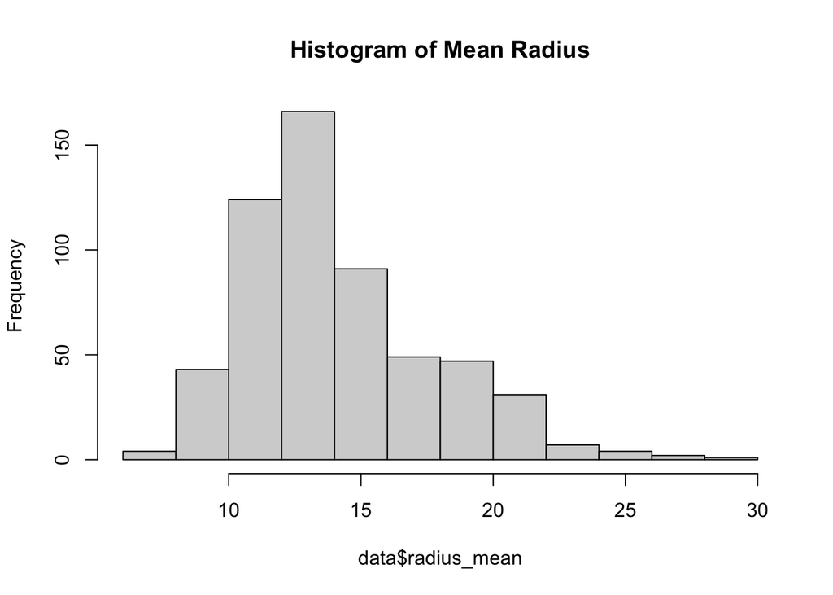

```r
#Key histograms:
hist(data$radius_mean,
     main = 'Histogram of Mean Radius')
```

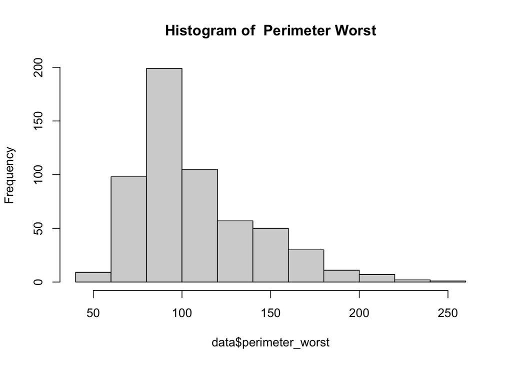

```r
#Key histograms:
hist(data$perimeter_worst,
     main = 'Histogram of  Perimeter Worst')
```

### Part 2

1. Preprocess the data for Naïve Bayes classification. Make sure to encode categorical variables (if any) and split the data into training and testing sets (70-30 split). Show your code and explain your preprocessing steps.

```r
#changing categorical variable diagnosis to a factor
data <- data %>%
  mutate(diagnosis_num = factor(diagnosis, levels = c("B", "M")))

#subsetting my data to not include id and diagnosis now that I have dianosis_num
data_subset <- data[, -c(1, 2)]

#The reason I am doing this is because the only column I am actually leaving out is ID, which is not need for my naive bayes classifier.
```

split the data into training and testing sets

```r
library(caret)
set.seed(123)

data_subset$diagnosis_num <- as.factor(data_subset$diagnosis_num)

#split 70 percent of the data
train_index <- createDataPartition(data_subset$diagnosis_num, p = 0.7, list = FALSE)

#create the training and testing data
train_data <- data_subset[train_index, ]
test_data <- data_subset[-train_index, ]
```

```r
#check the dimensions of the training and test data
dim(train_data)  # Should be ~70% of total rows -- 398 / 569 is close to 70%
```

```
## [1] 399  31
```

```r
dim(test_data)
```

```
## [1] 170  31
```

2. Train a Naïve Bayes classifier. Which are the features with the highest contribution to the classifier? Report the accuracy, sensitivity, and specificity of your model.

```r
y <- train_data$diagnosis_num
x <- train_data[, 1:30]

#Naïve Bayes classifier
model = train(x,y,'naive_bayes',trControl=trainControl(method='cv',number=10))

#print importance to show the highest contributions to the classifier
importance <- varImp(model)
print(importance)
```

```
## ROC curve variable importance
##
##   only 20 most important variables shown (out of 30)
##
##                      Importance
## perimeter_worst          100.00
## concave.points_worst      98.99
## radius_worst              98.88
## area_worst                98.58
## concave.points_mean       97.34
## perimeter_mean            93.79
## concavity_mean            93.54
## area_mean                 91.55
## radius_mean               91.50
## concavity_worst           91.06
## area_se                   88.73
## compactness_worst         79.98
## compactness_mean          79.41
## perimeter_se              77.39
## radius_se                 76.70
## concave.points_se         62.14
## concavity_se              61.70
## texture_worst             60.24
## texture_mean              59.57
## smoothness_worst          53.18
```

The **five features with the highest contribution to the classifier** are **perimeter_worst**, **concave.points_worst**, **radius_worst**, **area_worst**, and **concave.points_mean**.

Based on the confusion matrix I create in part 3, the **accuracy, sensitivity, and specificity** of the model is:

**Accuracy:** .9412

**Sensitivty:** .9346

**Specificity:** .9524

3. Create and interpret the confusion matrix. What does it tell you about the model’s performance? Are there any potential concerns regarding false positives or false negatives?

```r
#create the confusion matrix
Predict <- predict(model,newdata = test_data )
confusionMatrix(Predict, test_data$diagnosis_num)
```

```
## Confusion Matrix and Statistics
##
##           Reference
## Prediction   B   M
##          B 100   3
##          M   7  60
##
##                Accuracy : 0.9412
##                  95% CI : (0.8945, 0.9714)
##     No Information Rate : 0.6294
##     P-Value [Acc > NIR] : <0.0000000000000002
##
##                   Kappa : 0.8755
##
##  Mcnemar's Test P-Value : 0.3428
##
##             Sensitivity : 0.9346
##             Specificity : 0.9524
##          Pos Pred Value : 0.9709
##          Neg Pred Value : 0.8955
##              Prevalence : 0.6294
##          Detection Rate : 0.5882
##    Detection Prevalence : 0.6059
##       Balanced Accuracy : 0.9435
##
##        'Positive' Class : B
##
```

The confusion matrix with an accuracy of .9412, a sensitivity of .9346, and a specificity of .9524, tells us that our model **preforms well**.

4. Plot the ROC curve for your Naïve Bayes model and compute the AUC (Area Under the Curve). What does the AUC tell you about the classifier’s ability to distinguish between benign and malignant cases?

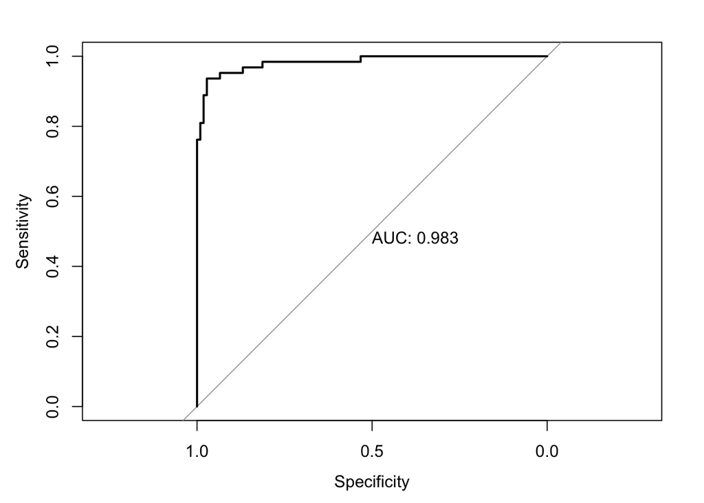

```r
##Plot ROC curve
library(pROC)
roc_ = roc(test_data$diagnosis_num, predict(model, newdata = test_data, type = "prob")[,2])
plot(roc_,print.auc=T)
```

The **AUC score of .983** tells us that the Naive Bayes classifier has a high ability to distinguish between benign and malignant cases. This suggests that the model is highly effective at correctly identifying cancerous tumors.